# Working with imagery

`mapSpain` provides a powerful interface for working with imagery. `mapSpain` can download static files as `.png` or`jpeg` files (depending on the Web Map Service) and use them along your shapefiles.

`mapSpain` also includes a plugin for **R** [leaflet](https://rstudio.github.io/leaflet/) package, that allows you to include several basemaps on your interactive maps.

The services are implemented via the leaflet plugin leaflet-providersESP. You can check a display of each provider on the previous link.

## Static tiles

An example of how you can include several tiles to create a static map. We focus here on the earthquakes of the last 365 days in the island of Tenerife. Note that the tile is actively maintained so the final plot based on a static file would vary depending on the date.

In this example, it is important to set `moveCAN = FALSE`, otherwise Tenerife would be geographically displaced while the imagery won’t.

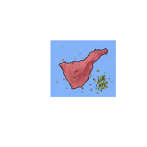

```r
library(mapSpain)
library(sf)
library(cartography)

Tenerife <- esp_get_nuts(region = "Tenerife", moveCAN = FALSE)
Tenerife <- st_transform(Tenerife, 4083)


Base <- esp_getTiles(Tenerife, "MDT.Relieve", bbox_expand = 0.2)
Earthquake <-
  esp_getTiles(Tenerife, "Geofisica.Terremotos365dias", bbox_expand = 0.2)

tilesLayer(Base)
plot(st_geometry(Tenerife),
     col = adjustcolor("red", alpha.f = 0.4),
     add = TRUE)
tilesLayer(Earthquake, add = TRUE)
```

Static tiles could be loaded with or without an alpha value, that controls the transparency of the object:

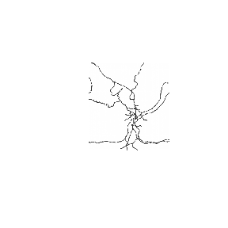

```r
Madrid <- esp_get_ccaa("Madrid", epsg = 3857)

# Example without transparency

BG <- esp_getTiles(Madrid, "IGNBase.Gris")
ADIF.opaque <-
  esp_getTiles(Madrid, "RedTransporte.Ferroviario",
               transparent = FALSE)

tilesLayer(BG)
plot(
  st_geometry(Madrid),
  col = adjustcolor("red", alpha.f = 0.2),
  add = TRUE,
  border = NA
)
tilesLayer(ADIF.opaque, add = TRUE)
```

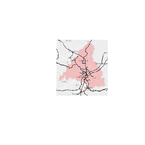

```r
# Example with transparency

ADIF.alpha <- esp_getTiles(Madrid,
                           "RedTransporte.Ferroviario")

tilesLayer(BG)
plot(
  st_geometry(Madrid),
  col = adjustcolor("red", alpha.f = 0.2),
  add = TRUE,
  border = NA
)
tilesLayer(ADIF.alpha, add = TRUE)
```

Another nice feature is the ability of masking the tiles, so more advanced maps can be plotted:

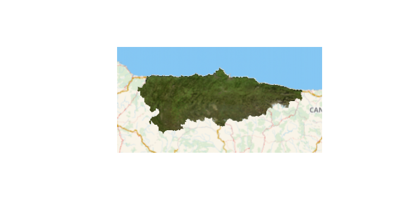

```r
Asturias <- esp_get_ccaa("Asturias", epsg = 3857)

Basemap <- esp_getTiles(Asturias, "IDErioja", bbox_expand = 0.3)

Mask <- esp_getTiles(Asturias, "PNOA", mask = TRUE)


tilesLayer(Basemap)
tilesLayer(Mask, add = TRUE)
```

## Dynamic maps with Leaflet

`mapSpain` provides a plugin to be used with the `leaflet` package. Here you can find the leaflet versions of some of the previous examples:

```r
library(leaflet)

Tenerife.leaf <-
  esp_get_nuts(region = "Tenerife",
               epsg = 4326,
               moveCAN = FALSE)


bbox <-
  as.double(round(st_bbox(Tenerife.leaf) + c(-1, -1, 1, 1), 2))

# Start leaflet
m <- leaflet(Tenerife.leaf,
             width = "100%",
             options = leafletOptions(minZoom = 9,
                                      maxZoom = 18))

# Add layers
m <- m %>%
  addProviderEspTiles("MDT.Relieve") %>%
  addPolygons(color = NA,
              fillColor = "red",
              group = "Polygon") %>%
  addProviderEspTiles("Geofisica.Terremotos365dias",
                      group = "Earthquakes")

# Add additional options
m  %>%
  addLayersControl(
    overlayGroups = c("Polygon", "Earthquakes"),
    options = layersControlOptions(collapsed = FALSE)
  ) %>% setMaxBounds(bbox[1], bbox[2], bbox[3], bbox[4])
```

[interactive chart not shown]

```r
Madrid.leaflet <- esp_get_ccaa("Madrid", epsg = 4326)

m2 <- leaflet(Madrid.leaflet, width = "100%") %>%
  addProviderEspTiles("IGNBase.Gris") %>%
  addPolygons(color = NA,
              fillColor = "red",
              group = "Polygon") %>%
  addProviderEspTiles("RedTransporte.Ferroviario",
                      group = "Railway")

# Add layer control

m2 %>% addLayersControl(
  overlayGroups = c("Polygon", "Railway"),
  options = layersControlOptions(collapsed = FALSE)
)
```

[interactive chart not shown]

## Available providers

The data frame `leaflet.providersESP.df` includes the data of the available providers you can use on functions described above. This data frame includes all the parameters needed to replicate the API request. In this summary only the parameter `url_static` is shown:

| provider | field | value |
| --- | --- | --- |
| IDErioja | url_static | https://rts.larioja.org/wmts/mapa_base_rioja?service=WMTS&request=GetTile&version=1.0.0&Format=image/png&layer=mapa_base_rioja&style=default&tilematrixset=GoogleMapsCompatible&TileMatrix={z}&TileRow={… |
| IGNBase | url_static | https://www.ign.es/wmts/ign-base?service=WMTS&request=GetTile&version=1.0.0&Format=image/png&layer=IGNBaseTodo&style=default&tilematrixset=GoogleMapsCompatible&TileMatrix={z}&TileRow={y}&TileCol={x} |
| IGNBase.Todo | url_static | https://www.ign.es/wmts/ign-base?service=WMTS&request=GetTile&version=1.0.0&Format=image/png&layer=IGNBaseTodo&style=default&tilematrixset=GoogleMapsCompatible&TileMatrix={z}&TileRow={y}&TileCol={x} |
| IGNBase.Gris | url_static | https://www.ign.es/wmts/ign-base?service=WMTS&request=GetTile&version=1.0.0&Format=image/jpeg&layer=IGNBase-gris&style=default&tilematrixset=GoogleMapsCompatible&TileMatrix={z}&TileRow={y}&TileCol={x} |
| IGNBase.TodoNoFondo | url_static | https://www.ign.es/wmts/ign-base?service=WMTS&request=GetTile&version=1.0.0&Format=image/png&layer=IGNBaseTodo-nofondo&style=default&tilematrixset=GoogleMapsCompatible&TileMatrix={z}&TileRow={y}&TileC… |
| IGNBase.Orto | url_static | https://www.ign.es/wmts/ign-base?service=WMTS&request=GetTile&version=1.0.0&Format=image/png&layer=IGNBaseOrto&style=default&tilematrixset=GoogleMapsCompatible&TileMatrix={z}&TileRow={y}&TileCol={x} |
| MDT | url_static | https://servicios.idee.es/wmts/mdt?service=WMTS&request=GetTile&version=1.0.0&Format=image/png&layer=EL.GridCoverage&style=default&tilematrixset=GoogleMapsCompatible&TileMatrix={z}&TileRow={y}&TileCol… |
| MDT.Elevaciones | url_static | https://servicios.idee.es/wmts/mdt?service=WMTS&request=GetTile&version=1.0.0&Format=image/png&layer=EL.GridCoverage&style=default&tilematrixset=GoogleMapsCompatible&TileMatrix={z}&TileRow={y}&TileCol… |
| MDT.Relieve | url_static | https://servicios.idee.es/wmts/mdt?service=WMTS&request=GetTile&version=1.0.0&Format=image/png&layer=Relieve&style=default&tilematrixset=GoogleMapsCompatible&TileMatrix={z}&TileRow={y}&TileCol={x} |
| MDT.CurvasNivel | url_static | http://www.ign.es/wms-inspire/mdt?SERVICE=WMS&VERSION=1.1.1&REQUEST=GetMap&FORMAT=image/png&TRANSPARENT=true&LAYERS=EL.ContourLine&SRS=EPSG:3857&WIDTH=512&HEIGHT=512&BBOX={bbox} |

[output cut: 85 more lines]

## Session Info

**Details**